# Ordinal regression in R: part 2

Taylor Dunn

2020-03-15

This is part 2 of learning ordinal regression in R. Previously, we explored the frequentist framework with the `ordinal` package. Here, we’ll use [`brms` package](https://cran.r-project.org/web/packages/brms/index.html) to fit Bayesian mixed models via Stan.

Though I won’t be reproducing their examples, Bürkner and Vuorre (2019) give a great tutorial of using `brms` for ordinal regression models. It also frames the cumulative model in the terms of a latent (not observable) continuous variable $\tilde{y}$, which has been categorized into the observed ordinal variable $y$. I found this way of thinking very intuitive, and it helped make a lot of the concepts click.

This post also serves as practice in Bayesian inference, so I’ll be comparing the results here to those from part 1, and explore different choices of prior distributions.

# Setup

Import all the packages, and the same `wine` data from Randall (1989) that we analyzed in part 1:

```r
library(tidyverse)
library(gt)
library(broom)
library(patchwork)
library(here)
library(tidybayes)
```

```r
# Set ggplot2 theme and defaults
theme_set(cowplot::theme_cowplot() + cowplot::background_grid(major = "xy"))
ggp <- function(...) ggplot(...) +
  scale_color_brewer(palette = "Set1") +
  scale_fill_brewer(palette = "Set1")

library(ordinal)
data(wine)
wine <- as_tibble(wine)
library(brms)
# Detect and set the number of cores for MCMC
options(mc.cores = parallel::detectCores())
```

# Bayesian regression

We will be fitting these models of `wine` bitterness `rating`s:

$$\begin{align}
\text{logit}(p(y_i \leq j)) &= \theta_j - u( \text{judge}_i) \\
\text{logit}(p(y_i \leq j)) &= \theta_j - \beta_1 \text{temp}_i - \beta_2 \text{contact}_i - u( \text{judge}_i) \\
\end{align}$$
where $p(y_i \leq j)$ is the probability of a `rating` less than or equal to $j$, $\theta_j$ are the thresholds for the $J-1 = 4$ levels, $u(\text{judge}_i)$ are judge-specific random effects, and $\beta_1$ and $\beta_2$ are fixed effect coefficients for $\text{temp}_i$ and $\text{contact}_i$. (See part 1 for more details).

```r
f_rating_null <- rating ~ 1 + (1|judge)
f_rating_contact_temp <- rating ~ 1 + contact + temp + (1|judge)
```

## Null model

We will start with the “null” model, with just thresholds and random effects. The default priors for this model are:

```r
get_prior(f_rating_null, data = wine, family = cumulative("logit"))
```

```
##                 prior     class      coef group resp dpar nlpar bound
## 1 student_t(3, 0, 10) Intercept
## 2                     Intercept         1
## 3                     Intercept         2
## 4                     Intercept         3
## 5                     Intercept         4
## 6 student_t(3, 0, 10)        sd
## 7                            sd           judge
## 8                            sd Intercept judge
```

$$\begin{align}
\text{logit}(p(y_i \leq j)) &= \theta_j - u( \text{judge}_i) \\
\theta_j &\sim \text{Student-}t(3, 0, 10) \\
u(\text{judge}_i) &\sim \text{Normal}(0, \sigma_u) \\
\sigma_u &\sim \text{Student-} t(3, 0, 10)
\end{align}$$

Fit the model:

```r
brm_rating_null <-
  brm(
    f_rating_null,
    data = wine,
    family = cumulative("logit"),
    sample_prior = TRUE,
    file = "brm_rating_null"
  )
```

We can visualize the two priors (on thresholds/Intercepts, and on SD of judge effects) with `brms:prior_samples`:

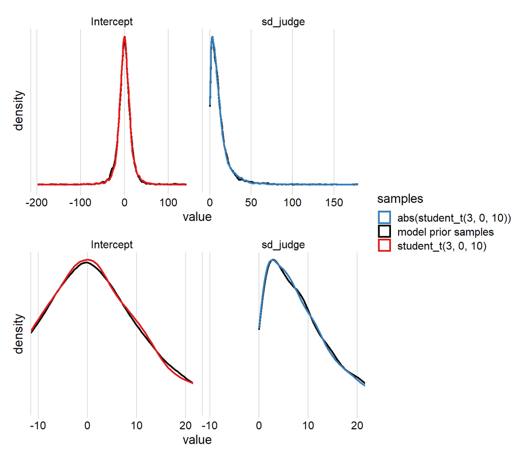

```r
p1 <-
  prior_samples(brm_rating_null) %>%
  gather(term, value) %>%
  mutate(samples = "model prior samples") %>%
  ggplot(aes(x = value, color = samples)) +
  geom_density(size = 1) +
  # We can get prior samples without fitting a model of course: just random
  #  sampling from the appropriate distribution
  geom_density(
    data = tibble(value = rstudent_t(n = 4000, df = 3, mu = 0, sigma = 10),
                  samples = "student_t(3, 0, 10)", term = "Intercept"),
    size = 1
  ) +
  geom_density(
    data = tibble(value = abs(rstudent_t(n = 4000, df = 3, mu = 0, sigma = 10)),
                  samples = "abs(student_t(3, 0, 10))", term = "sd_judge"),
    size = 1,
  ) +
  facet_wrap(~term, scales = "free") +
  cowplot::theme_minimal_vgrid() +
  scale_color_manual(
    values = c("model prior samples" = "black",
               "student_t(3, 0, 10)" = "#E41A1C",
               "abs(student_t(3, 0, 10))" = "#377EB8")
  ) +
  theme(axis.text.y = element_blank(),
        axis.ticks.y = element_blank())
p1 +
  (p1 + coord_cartesian(xlim = c(-10, 20))) +
  plot_layout(ncol = 1, guides = "collect")
```

Note that, since a standard deviation can’t be negative, `brms` automatically takes the absolute value of the default `student_t(3, 0, 10)` prior.

These are obviously very uninformative priors. For instance, Intercepts (the thresholds $\theta_j$) between -20 and +20 correspond to the following probabilities:

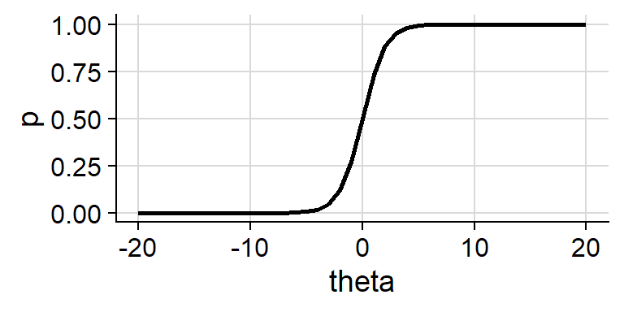

```r
tibble(theta = seq(-20, 20)) %>%
  mutate(p = inv_logit_scaled(theta)) %>%
  ggp(aes(x = theta, y = p)) +
  geom_line(size = 1)
```

So any prior values of, say, -10 are assigning essentially zero cumulative probability for a level $\leq j$.

Now that we’ve thought about our (default) prior assumptions, investigate the chains:

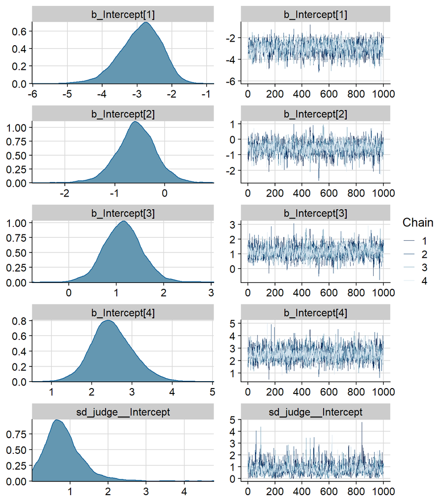

```r
plot(brm_rating_null)
```

The Intercept trace plots look good to me. There are some spikes in `sd_judge__Intercept`, but not enough to be concerning.

Print the model estimates:

```r
brm_rating_null
```

```
##  Family: cumulative
##   Links: mu = logit; disc = identity
## Formula: rating ~ 1 + (1 | judge)
##    Data: wine (Number of observations: 72)
## Samples: 4 chains, each with iter = 2000; warmup = 1000; thin = 1;
##          total post-warmup samples = 4000
##
## Group-Level Effects:
## ~judge (Number of levels: 9)
##               Estimate Est.Error l-95% CI u-95% CI Rhat Bulk_ESS Tail_ESS
## sd(Intercept)     0.83      0.48     0.07     1.97 1.00     1139     1042
##
## Population-Level Effects:
##              Estimate Est.Error l-95% CI u-95% CI Rhat Bulk_ESS Tail_ESS
## Intercept[1]    -2.90      0.59    -4.15    -1.90 1.00     2064     2230
## Intercept[2]    -0.58      0.40    -1.39     0.20 1.00     2389     2617
## Intercept[3]     1.14      0.41     0.34     1.95 1.00     2347     2806
## Intercept[4]     2.51      0.52     1.53     3.61 1.00     3032     2792
##
## Samples were drawn using sampling(NUTS). For each parameter, Eff.Sample
## is a crude measure of effective sample size, and Rhat is the potential
## scale reduction factor on split chains (at convergence, Rhat = 1).
```

The `Rhat` values are also a good sign of model convergence. Another thing we can do is a posterior predictive check:

```r
pp_check(brm_rating_null)
```

```
## Using 10 posterior samples for ppc type 'dens_overlay' by default.
```

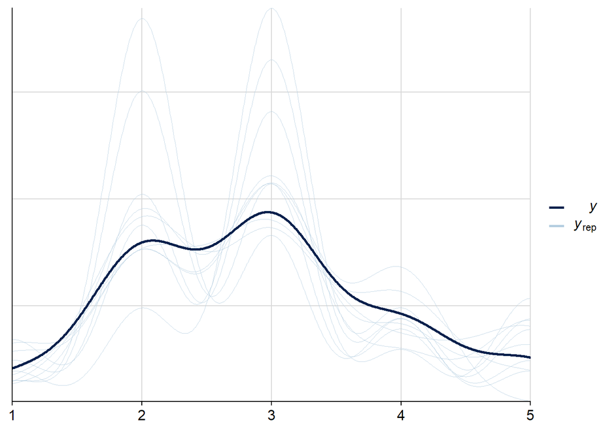

Compare our null Bayesian model estimates to the frequentist estimates:

```r
# Can't figure out how to extract random effect SDs from a clmm model, use clmm2
clmm2_rating_null <-
  clmm2(
    rating ~ 1, random = judge,
    data = wine, link = "logistic", Hess = TRUE
  )
# Unfortunately, clmm2 doesn't have a broom::tidy() function
summary(clmm2_rating_null) %>%
  coef() %>%
  as_tibble() %>%
  mutate(term = str_c("b_Intercept[", 1:4, "]")) %>%
  bind_rows(
    tibble(
      Estimate = as.numeric(clmm2_rating_null$stDev),
      term = "sd_judge__Intercept"
    )
  ) %>%
  janitor::clean_names() %>%
  left_join(
    tidy(brm_rating_null),
    by = "term"
  ) %>%
  select(term, everything()) %>%
  mutate(
    pr_z = scales::pvalue(pr_z),
    across(is.numeric, ~round(., 2))
  ) %>%
  gt() %>%
  tab_spanner(
    label = "ordinal::clmm",
    columns = vars(estimate.x, std_error, z_value, pr_z)
  ) %>%
  tab_spanner(
    label = "brms::brm",
    columns = vars(estimate.y, std.error, lower, upper)
  ) %>%
  fmt_missing(columns = everything(), missing_text = "")
```

| term | ordinal::clmm estimate.x | ordinal::clmm std_error | ordinal::clmm z_value | ordinal::clmm pr_z | brms::brm estimate.y | brms::brm std.error | brms::brm lower | brms::brm upper |
| --- | --- | --- | --- | --- | --- | --- | --- | --- |
| b_Intercept[1] | -2.72 | 0.52 | -5.25 | <0.001 | -2.90 | 0.59 | -3.94 | -2.02 |
| b_Intercept[2] | -0.54 | 0.32 | -1.72 | 0.085 | -0.58 | 0.40 | -1.23 | 0.07 |
| b_Intercept[3] | 1.10 | 0.34 | 3.24 | 0.001 | 1.14 | 0.41 | 0.50 | 1.81 |
| b_Intercept[4] | 2.35 | 0.46 | 5.13 | <0.001 | 2.51 | 0.52 | 1.70 | 3.42 |
| sd_judge__Intercept | 0.57 |  |  |  | 0.83 | 0.48 | 0.16 | 1.69 |

Frequentist estimates are pretty close to the Bayesian estimates with naive priors.

### Choice of priors

So what are reasonable priors for this data and model? My go-to resource for this kind of thing is [this page from the stan wiki](https://github.com/stan-dev/stan/wiki/Prior-Choice-Recommendations), but under the “Prior for cutpoints in ordered logit or probit regression”, they have a couple suggestions like “uniform priors typically should be ok”, but also say “Need to flesh out this section with examples”, so not a lot of help there.

Let’s consider the following priors on the the thresholds:

$$\begin{align}
\theta_j &\sim \text{Student-}t(3, 0, 10) \\
\theta_j &\sim \text{Student-}t(3, 0, 5) \\
\theta_j &\sim \text{Student-}t(3, 0, 2) \\
\theta_j &\sim \text{Normal}(0, 10) \\
\theta_j &\sim \text{Normal}(0, 5) \\
\theta_j &\sim \text{Normal}(0, 2)
\end{align}$$

and simulate some corresponding cumulative probabilities:

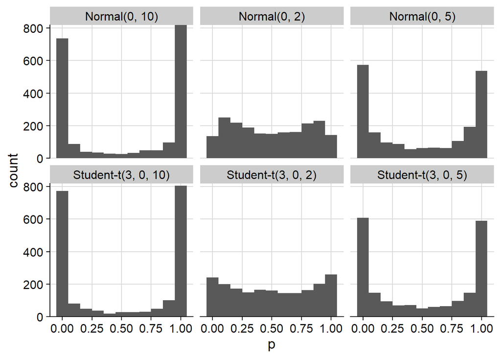

```r
tibble(
  std_dev = c(10, 5, 2)
) %>%
  mutate(
    prior = str_c("Normal(0, ", std_dev, ")"),
    samples = map(std_dev, ~rnorm(2000, mean = 0, sd = .x))
  ) %>%
  bind_rows(
    tibble(sigma = c(10, 5, 2)) %>%
      mutate(prior = str_c("Student-t(3, 0, ", sigma, ")"),
             samples = map(sigma, ~rstudent_t(2000, df = 3, mu = 0, sigma = .x)))
  ) %>%
  unnest(samples) %>%
  mutate(p = inv_logit_scaled(samples)) %>%
  ggp(aes(x = p)) +
  geom_histogram(binwidth = 0.1) +
  facet_wrap(~prior) +
  scale_y_continuous(expand = c(0, 0))
```

To my eye, the $\text{Normal}(0, 10)/\text{Student-}t(3, 0, 10)$ and $\text{Normal}(0, 5)/\text{Student-}t(3, 0, 5)$ are not ideal because they place most of the samples are at the extremes (cumulative probabilities of 0 and 100%). $\text{Normal}(0, 2)$ and $\text{Student-}t(3, 0, 2)$ are much more equal in terms of sampling the “probability” space.

As for the scale parameter describing the variance in judge-specific random effects, I’ve seen the [half-Cauchy distribution recommended](https://github.com/stan-dev/stan/wiki/Prior-Choice-Recommendations):

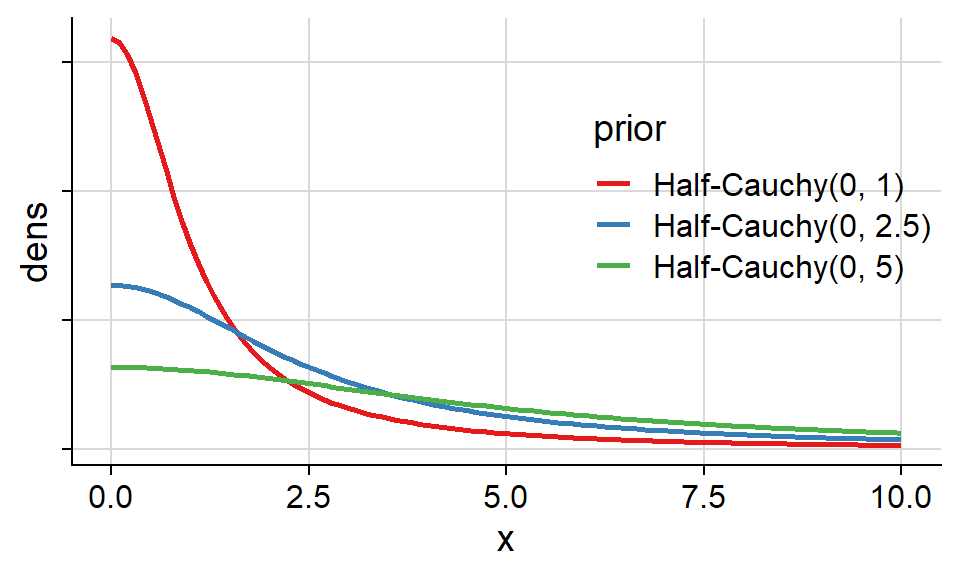

```r
tibble(scale = c(1, 2.5, 5)) %>%
  crossing(x = seq(0, 10, 0.1)) %>%
  mutate(
    prior = str_c("Half-Cauchy(0, ", scale, ")"),
    dens = dcauchy(x, location = 0, scale = scale)
  ) %>%
  ggp(aes(x, y = dens)) +
  geom_line(aes(color = prior), size = 1) +
  theme(legend.position = c(0.6, 0.6),
        axis.text.y = element_blank())
```

This distribution is fairly conservative, with a long right tail that allows for large values.

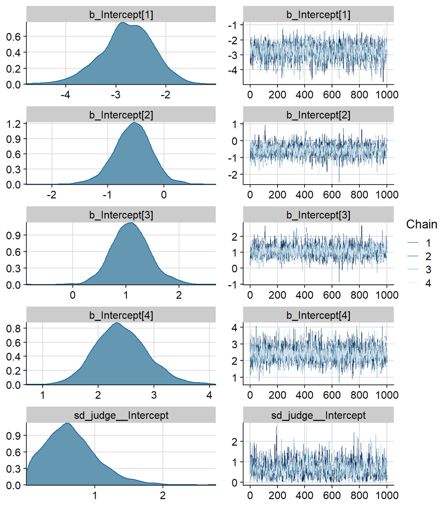

```r
prior_rating_null <- c(
  prior(normal(0, 2.5), class = Intercept),
  prior(cauchy(0, 1), class = sd)
)
brm_rating_null_weak_prior <-
  brm(
    f_rating_null,
    prior = prior_rating_null ,
    data = wine,
    family = cumulative("logit"),
    file = "brm_rating_null_weak_prior"
  )
plot(brm_rating_null_weak_prior)
```

This doesn’t massively improve the model convergence (which, to be fair, was already good). There are fewer large `sd_judge__Intercept` values in the posterior. The model estimates changed only slightly:

```r
tidy(brm_rating_null) %>%
  mutate(priors = "default priors") %>%
  bind_rows(
    tidy(brm_rating_null_weak_prior) %>%
      mutate(priors = "weak priors")
  ) %>%
  filter(term != "lp__", !str_starts(term, "r_|prior_")) %>%
  transmute(
    term,
    estimate_se = str_c(round(estimate, 2), " (", round(std.error, 2), ")"),
    priors
  ) %>%
  spread(priors, estimate_se) %>%
  gt()
```

| term | default priors | weak priors |
| --- | --- | --- |
| b_Intercept[1] | -2.9 (0.59) | -2.78 (0.53) |
| b_Intercept[2] | -0.58 (0.4) | -0.56 (0.34) |
| b_Intercept[3] | 1.14 (0.41) | 1.09 (0.37) |
| b_Intercept[4] | 2.51 (0.52) | 2.41 (0.48) |
| sd_judge__Intercept | 0.83 (0.48) | 0.66 (0.38) |

So although the default priors really don’t describe the data or our expectations very well, they do just fine in estimating the model coefficients.

## Fixed effects

We now add the “treatment” effects of `temp` and `contact`:

$$\begin{align}
\text{logit}(p(y_i \leq j)) &= \theta_j - \beta_1 \text{temp}_i - \beta_2 \text{contact}_i - u( \text{judge}_i) \\
\end{align}$$

This introduces two new priors we can specify:

```r
get_prior(f_rating_contact_temp, data = wine, family = cumulative("logit"))
```

```
##                  prior     class       coef group resp dpar nlpar bound
## 1                              b
## 2                              b contactyes
## 3                              b   tempwarm
## 4  student_t(3, 0, 10) Intercept
## 5                      Intercept          1
## 6                      Intercept          2
## 7                      Intercept          3
## 8                      Intercept          4
## 9  student_t(3, 0, 10)        sd
## 10                            sd            judge
## 11                            sd  Intercept judge
```

We know from part 1 that `contactyes` ($\beta_1$) and `tempwarm` ($\beta_2$) are associated with higher ratings, but we shouldn’t be biasing our priors by using the same data we are modeling. Instead, use a weakly regularizing normal distributions centered at 0:

```r
prior_rating_contact_temp <-
  c(prior_rating_null,
    prior(normal(0, 5), class = b))

brm_rating_contact_temp <-
  brm(
    f_rating_contact_temp,
    prior = prior_rating_contact_temp,
    data = wine,
    family = cumulative("logit"),
    file = "brm_rating_contact_temp_weak_prior"
  )
# Also fit using the default priors
brm_rating_contact_temp_default_prior <-
  brm(
    f_rating_contact_temp,
    data = wine,
    family = cumulative("logit"),
    sample_prior = TRUE,
    file = "brm_rating_contact_temp_default_prior"
  )
brm_rating_contact_temp
```

```
##  Family: cumulative
##   Links: mu = logit; disc = identity
## Formula: rating ~ 1 + contact + temp + (1 | judge)
##    Data: wine (Number of observations: 72)
## Samples: 4 chains, each with iter = 2000; warmup = 1000; thin = 1;
##          total post-warmup samples = 4000
##
## Group-Level Effects:
## ~judge (Number of levels: 9)
##               Estimate Est.Error l-95% CI u-95% CI Rhat Bulk_ESS Tail_ESS
## sd(Intercept)     1.20      0.45     0.49     2.22 1.00     1254     1034
##
## Population-Level Effects:
##              Estimate Est.Error l-95% CI u-95% CI Rhat Bulk_ESS Tail_ESS
## Intercept[1]    -1.59      0.66    -2.89    -0.37 1.00     2398     2673
## Intercept[2]     1.44      0.59     0.32     2.65 1.00     2676     2956
## Intercept[3]     4.05      0.76     2.66     5.68 1.00     2489     2594
## Intercept[4]     5.89      0.89     4.23     7.71 1.00     2539     3283
## contactyes       1.76      0.49     0.81     2.73 1.00     3403     3017
## tempwarm         2.95      0.55     1.92     4.05 1.00     2933     3337
##
## Samples were drawn using sampling(NUTS). For each parameter, Eff.Sample
## is a crude measure of effective sample size, and Rhat is the potential
## scale reduction factor on split chains (at convergence, Rhat = 1).
```

Compare these estimates to those from `clmm` and with default priors:

```r
clmm2_rating_contact_temp <-
  clmm2(
    rating ~ contact + temp, random = judge,
    data = wine, link = "logistic", Hess = TRUE
  )

tidy(brm_rating_contact_temp) %>%
  mutate(model = "brm weak priors") %>%
  bind_rows(
    tidy(brm_rating_contact_temp_default_prior) %>%
      mutate(model = "brm default priors")
  ) %>%
  filter(!str_detect(term, "r_judge|lp__|prior")) %>%
  transmute(
    term, model,
    estimate_se = str_c(round(estimate, 2), " (", round(std.error, 2), ")")
  ) %>%
  bind_rows(
    summary(clmm2_rating_contact_temp) %>%
      coef() %>%
      as_tibble() %>%
      mutate(term = c(str_c("b_Intercept[", 1:4, "]"),
                      "b_contactyes", "b_tempwarm")) %>%
      bind_rows(
        tibble(
          Estimate = as.numeric(clmm2_rating_contact_temp$stDev),
          term = "sd_judge__Intercept"
        )
      ) %>%
      janitor::clean_names() %>%
      transmute(
        model = "clmm", term,
        estimate_se = ifelse(
          !is.na(std_error),
          str_c(round(estimate, 2), " (", round(std_error, 2), ")"),
          round(estimate, 2)
        )
      )
  ) %>%
  spread(model, estimate_se) %>%
  gt()
```

| term | brm default priors | brm weak priors | clmm |
| --- | --- | --- | --- |
| b_contactyes | 1.98 (0.53) | 1.76 (0.49) | 1.83 (0.51) |
| b_Intercept[1] | -1.76 (0.83) | -1.59 (0.66) | -1.62 (0.68) |
| b_Intercept[2] | 1.65 (0.76) | 1.44 (0.59) | 1.51 (0.6) |
| b_Intercept[3] | 4.57 (0.98) | 4.05 (0.76) | 4.23 (0.81) |
| b_Intercept[4] | 6.6 (1.15) | 5.89 (0.89) | 6.09 (0.97) |
| b_tempwarm | 3.31 (0.64) | 2.95 (0.55) | 3.06 (0.6) |
| sd_judge__Intercept | 1.62 (0.65) | 1.2 (0.45) | 1.13 |

# Aside: adjacent-category models

Here are what Bürkner and Vuorre (2019) had to say about the adjacent-category class of ordinal models.

- Predict the decision between two adjacent categories $k$ and $k+1$
- Latent variables $\tilde{Y}_k$ with thresholds $\tau_k$ and cumulative distribution function $F$
- If $\tilde{Y}_k < \tau_k$, we choose category $k$; $k+1$ otherwise
- It is difficult to think of a natural process leading to them; chosen for its mathematical convenience rather than quality of interpretation

Mathematically:

$$\text{Pr}(Y = k | Y \in \{k, k+1\}) = F(\tau_k)$$

```r
brm_rating_contact_temp_default_prior_acat <-
  brm(
    f_rating_contact_temp,
    family = acat(link = "logit"),
    data = wine,
    file = "brm_rating_contact_temp_default_prior_acat"
  )
```

How do these estimates compare to the cumulative model?

```r
tidy(brm_rating_contact_temp_default_prior) %>%
  mutate(model = "cumulative") %>%
  bind_rows(
    tidy(brm_rating_contact_temp_default_prior_acat) %>%
      mutate(model = "adjacent-category")
  ) %>%
  filter(!str_detect(term, "r_judge|lp__|prior")) %>%
  transmute(
    term, model,
    estimate_se = str_c(round(estimate, 2), " (", round(std.error, 2), ")")
  ) %>%
  spread(model, estimate_se) %>%
  gt()
```

| term | adjacent-category | cumulative |
| --- | --- | --- |
| b_contactyes | 1.48 (0.43) | 1.98 (0.53) |
| b_Intercept[1] | -1.42 (0.74) | -1.76 (0.83) |
| b_Intercept[2] | 1.32 (0.63) | 1.65 (0.76) |
| b_Intercept[3] | 3.72 (0.88) | 4.57 (0.98) |
| b_Intercept[4] | 4.61 (1.15) | 6.6 (1.15) |
| b_tempwarm | 2.58 (0.58) | 3.31 (0.64) |
| sd_judge__Intercept | 1.23 (0.52) | 1.62 (0.65) |

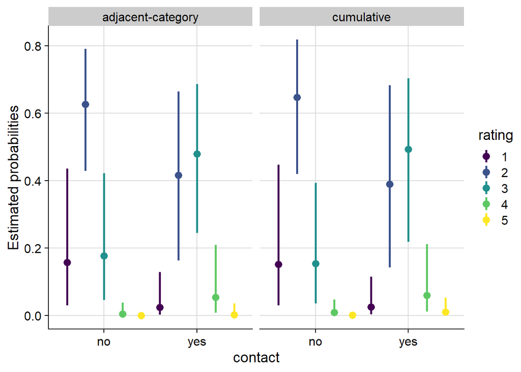

```r
me_rating_contact_temp_default_prior_acat <-
  marginal_effects(brm_rating_contact_temp_default_prior_acat, categorical = T,
                   re_formula = NA, ask = F)

me_rating_contact_temp_default_prior <-
  marginal_effects(brm_rating_contact_temp_default_prior, categorical = T,
                   re_formula = NA, ask = F)

me_rating_contact_temp_default_prior_acat$`contact:cats__` %>%
  mutate(model = "adjacent-category") %>%
  bind_rows(
    me_rating_contact_temp_default_prior$`contact:cats__` %>%
      mutate(model = "cumulative")
  ) %>%
  ggplot(aes(x = contact, y = estimate__, color = effect2__)) +
  geom_point(position = position_dodge(1), size = 3) +
  geom_linerange(aes(ymin = lower__, ymax = upper__),
                 position = position_dodge(1), size = 1) +
  facet_wrap(~model) +
  scale_color_viridis_d() +
  labs(y = "Estimated probabilities", color = "rating")
```

The model classes are essentially the same.

# Category-specific effects

In all of the models specified so far, all fixed effects were presumed to affect all response categories equally. For example, the effect of `temp` = warm had a mean effect of $\beta_1$ = 2.95 on the thresholds $\theta_j$, for all $j = 1, 2, 3, 4$.

This may not be an appropriate assumption. For example, `temp` warm might have little relation to the highest `rating`, but it may strongly predict `rating`s of 3 relative to 1 or 2.

If this is a possibility, then we can model the predictor as having a *category-sepcific* effect by estimating $K-1$ coefficients for it. The reason we’ve introduced the adjacent-category model is that it is unproblematic to incorporate these effects (sequential models work as well). Cumulative models, however, can lead to negative probabilities, and so should be avoided when using category-specific effects.

Fit the adjacent-category model with category-specific effects on `temp`:

$$\begin{align}
\text{logit}(p(y_i \leq j)) &= \theta_j - \beta_{1j} \text{temp}_i - \beta_2 \text{contact}_i - u( \text{judge}_i) \\
\text{logit}(p(y_i \leq j)) &= \theta_j - \beta_{1j} \text{temp}_i - u( \text{judge}_i) \\
\end{align}$$

```r
f_rating_cs_temp <- rating ~ 1 + cs(temp) + (1|judge)
# Note that category-specific priors aren't available
#get_prior(f_rating_cs_temp, data = wine, family = acat(link = "logit"))

brm_rating_cs_temp_default_prior_acat <-
  brm(
    f_rating_cs_temp,
    family = acat(link = "logit"),
    data = wine,
    file = "brm_rating_cs_temp_default_prior_acat"
  )
```

There were many divergent transitions. Investigate the trace plots:

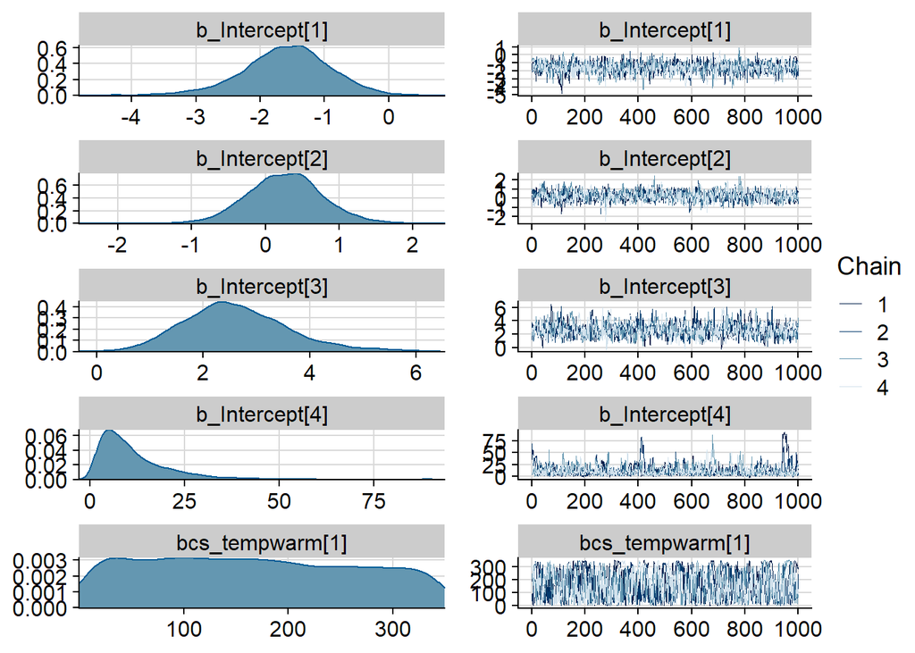

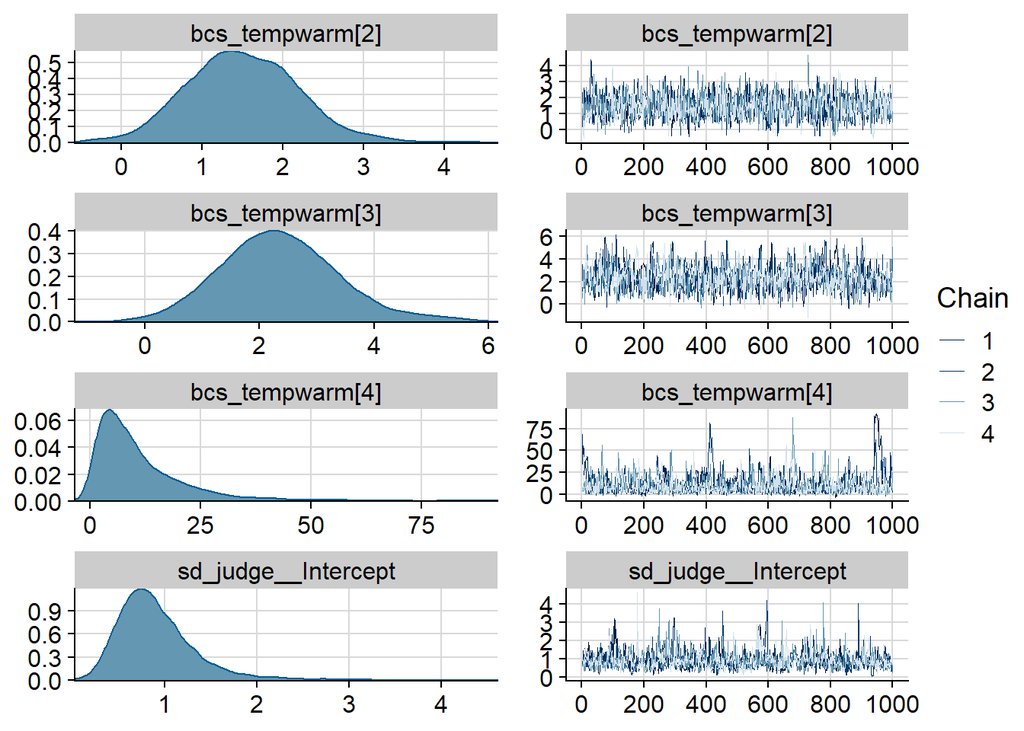

```r
plot(brm_rating_cs_temp_default_prior_acat)
```

Most of the divergence is coming from estimating the lowest and highest coefficients $\beta_{11}$ and $\beta_{14}$. We will try some regularizing priors and increasing the `adapt_delta` argument:

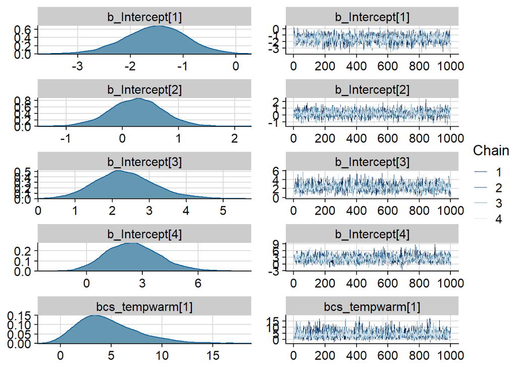

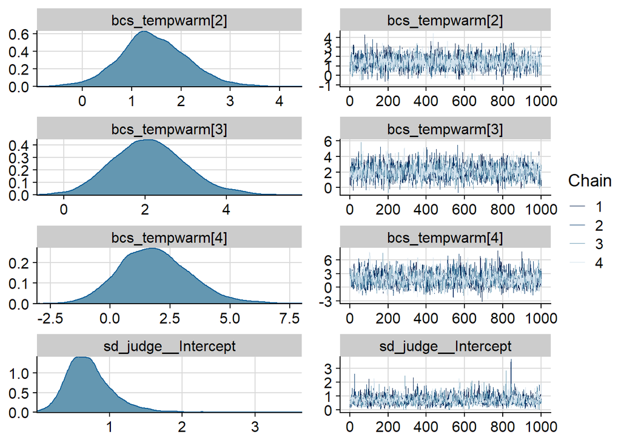

```r
brm_rating_cs_temp_weak_prior_acat <-
  brm(
    f_rating_cs_temp,
    prior = prior_rating_contact_temp,
    family = acat(link = "logit"),
    data = wine,
    file = "brm_rating_cs_temp_weak_prior_acat",
    control = list(adapt_delta = 0.9)
  )
plot(brm_rating_cs_temp_weak_prior_acat)
```

This makes a huge difference. Compare to a model without category-specific effects:

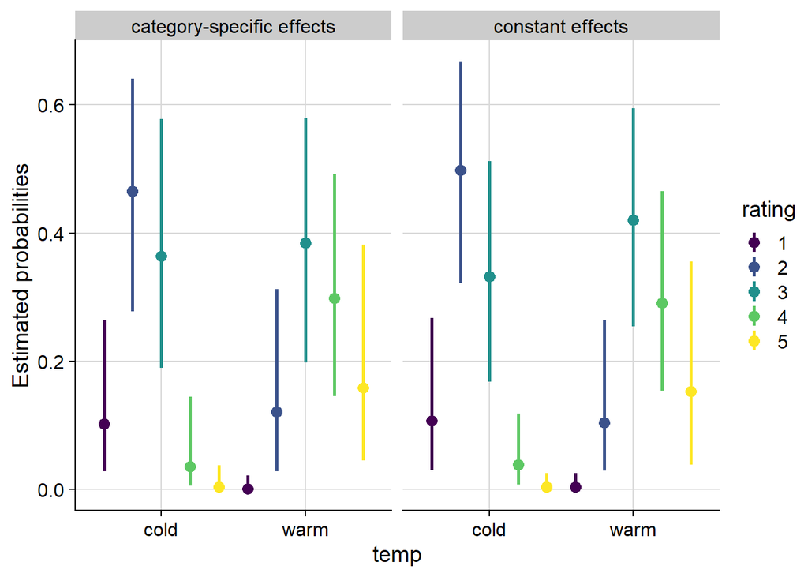

```r
me_rating_cs_temp_weak_prior_acat <-
  marginal_effects(brm_rating_cs_temp_weak_prior_acat, categorical = T,
                   re_formula = NA, ask = F)
brm_rating_temp_weak_prior_acat <-
  brm(
    rating ~ 1 + temp + (1|judge),
    prior = prior_rating_contact_temp,
    family = acat(link = "logit"),
    data = wine,
    file = "brm_rating_temp_weak_prior_acat"
  )
me_rating_temp_weak_prior_acat <-
  marginal_effects(brm_rating_temp_weak_prior_acat, categorical = T,
                   re_formula = NA, ask = F)

me_rating_temp_weak_prior_acat$`temp:cats__` %>%
  mutate(model = "constant effects") %>%
  bind_rows(
    me_rating_cs_temp_weak_prior_acat$`temp:cats__` %>%
      mutate(model = "category-specific effects")
  ) %>%
  ggplot(aes(x = temp, y = estimate__, color = effect2__)) +
  geom_point(position = position_dodge(1), size = 3) +
  geom_linerange(aes(ymin = lower__, ymax = upper__),
                 position = position_dodge(1), size = 1) +
  facet_wrap(~model) +
  scale_color_viridis_d() +
  labs(y = "Estimated probabilities", color = "rating")
```

Or, put the probabilities for each model side-by-side, along with the empirical probabilities:

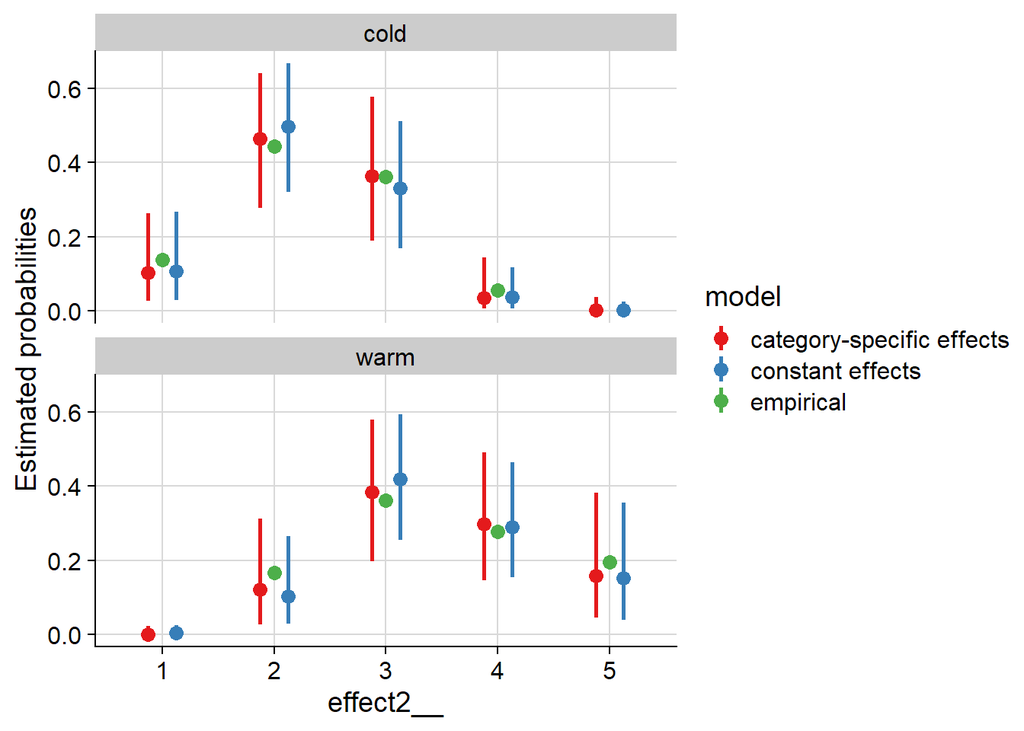

```r
me_rating_temp_weak_prior_acat$`temp:cats__` %>%
  mutate(model = "constant effects") %>%
  bind_rows(
    me_rating_cs_temp_weak_prior_acat$`temp:cats__` %>%
      mutate(model = "category-specific effects")
  ) %>%
  ggp(aes(x = effect2__, y = estimate__, color = model)) +
  geom_point(position = position_dodge(0.5), size = 3) +
  geom_linerange(aes(ymin = lower__, ymax = upper__),
                 position = position_dodge(0.5), size = 1) +
  geom_point(
    data = wine %>%
      group_by(temp, rating) %>%
      tally() %>%
      group_by(temp) %>%
      mutate(p = n / sum(n), model = "empirical"),
    aes(x = rating, y = p, color = model), size = 3
  ) +
  facet_wrap(~temp, ncol = 1) +
  labs(y = "Estimated probabilities", color = "model")
```

```r
brm_rating_temp_weak_prior_acat <-
  add_criterion(brm_rating_temp_weak_prior_acat, "waic")
brm_rating_cs_temp_weak_prior_acat <-
  add_criterion(brm_rating_cs_temp_weak_prior_acat, "waic")
loo_compare(
  brm_rating_temp_weak_prior_acat,
  brm_rating_cs_temp_weak_prior_acat,
  criterion = "waic"
)
```

```
##                                    elpd_diff se_diff
## brm_rating_temp_weak_prior_acat     0.0       0.0
## brm_rating_cs_temp_weak_prior_acat -1.0       0.7
```

# References

Bürkner, Paul-Christian, and Matti Vuorre. 2019. “Ordinal Regression Models in Psychology: A Tutorial.” *Advances in Methods and Practices in Psychological Science* 2 (1): 77–101. https://doi.org/10.1177/2515245918823199.

Randall, J. H. 1989. “The Analysis of Sensory Data by Generalized Linear Model.” *Biometrical Journal* 31 (7): 781–93. https://doi.org/10.1002/bimj.4710310703.